# Julia on HPC

CounterfactualExplanations.jl meets Supercomputing

[Patrick Altmeyer](https://www.patalt.org/)

Delft University of Technology

October 13, 2026

## Agenda

- Introduction to Parallel Computing (15 min).
  1. What is parallel computing?
  2. Parallel computing in Julia.
  3. Different forms of [parallelization](https://juliatrustworthyai.github.io/CounterfactualExplanations.jl/stable/tutorials/parallelization/) offered by CounterfactualExplanations.jl.
- First interactive session: local parallelization (15 min).
- Julia on [DelftBlue](https://www.tudelft.nl/dhpc/system) (25 min).
  1. What is DelftBlue?
  2. How to use Julia on DelftBlue?
  3. Challenges and solutions.
- Second interactive session: remote parallelization (25 min).

# Introduction to Parallel Computing

## What is Parallel Computing?

> Parallel computing is a type of computation in which many calculations or processes are carried out simultaneously. — [Wikipedia](https://en.wikipedia.org/wiki/Parallel_computing)

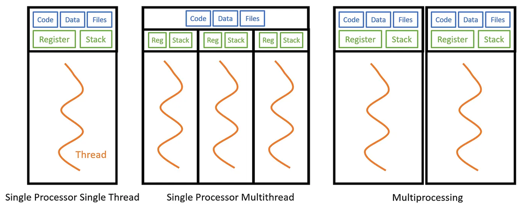

Image by [Kay Jan Wong](https://towardsdatascience.com/multithreading-and-multiprocessing-in-10-minutes-20d9b3c6a867).

## Parallel Computing in Julia

Julia has strong native and external support for parallel computing.

#### [Multi-Threading](https://docs.julialang.org/en/v1/manual/multi-threading/#man-multithreading)

Command line:

```bash
julia --threads 4
```

Julia:

```julia
Threads.@threads for i = 1:10
    a[i] = Threads.threadid()
end
```

#### [Multi-Processing](https://docs.julialang.org/en/v1/manual/distributed-computing/)

- [Distributed](https://docs.julialang.org/en/v1/stdlib/Distributed/#man-distributed) standard library (not covered here).
- [MPI.jl](https://juliaparallel.org/MPI.jl/latest/) wrapper for [MPI](https://en.wikipedia.org/wiki/Message_Passing_Interface) (our focus).

## Parallelization in CounterfactualExplanations.jl

- Motivation: often required to generate many explanations.
- Goal: native support for both forms of [parallelization](https://juliatrustworthyai.github.io/CounterfactualExplanations.jl/stable/tutorials/parallelization/).
- Desiteratum: minimize the burden on users.

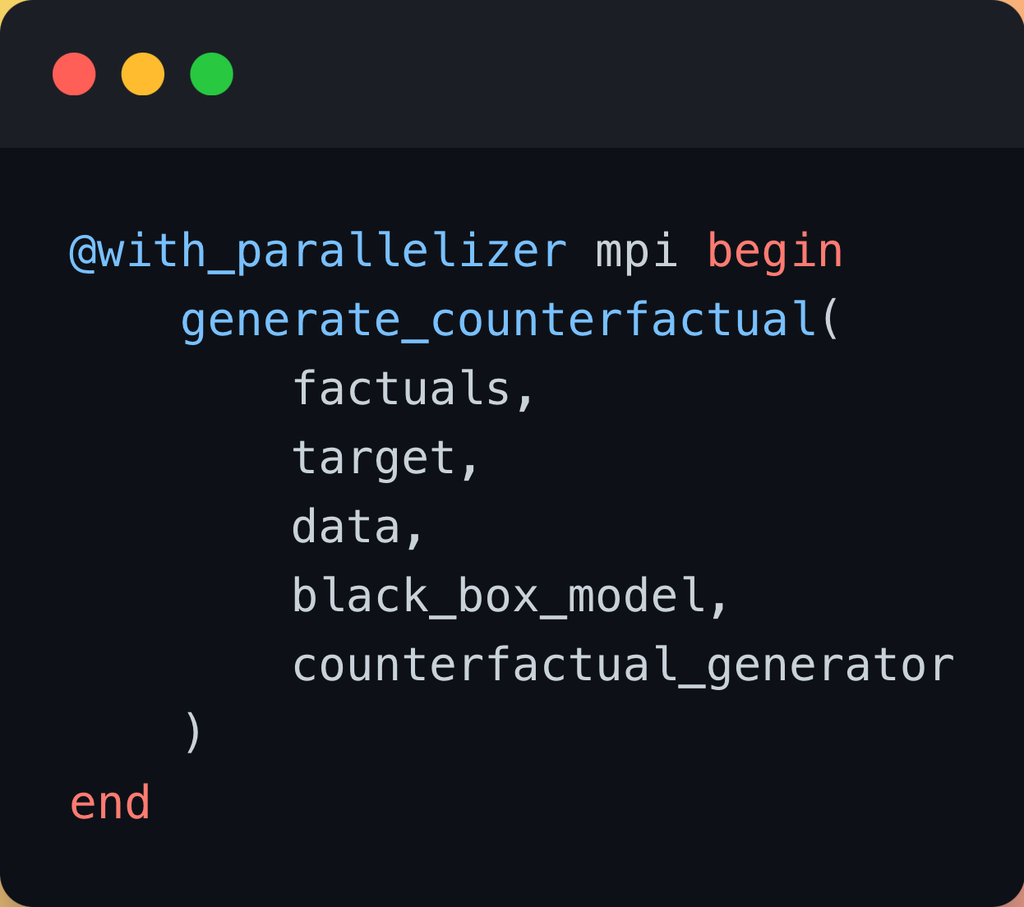

Usage example.

# First Interactive Session: Local Parallelization

## Tasks (15 min)

1. If not already done, either fork or clone the [repo](https://github.com/JuliaTrustworthyAI/CounterfactualExplanations.jl).
2. Open the notebook `docs/src/tutorials/parallelization.qmd`.
3. Using the `@time` macro, check if multi-threading speeds up computations.

# Julia on DelftBlue

## What is DelftBlue?

> DelftBlue is [one of two] supercomputer[s] at TU Delft [that] will offer 20,000 CPU cores in over 400 compute nodes. — [DelftBlue](https://www.tudelft.nl/dhpc/system)
- Rich [documentation](https://doc.dhpc.tudelft.nl/delftblue/Accounting-and-shares/) including a small section on [Julia](https://doc.dhpc.tudelft.nl/delftblue/howtos/Julia-with-MPI/).
- Should be accessible to all of you.
- You will be among the first to use Julia on DelftBlue.
- Alternative: [DAIC](https://doc.daic.tudelft.nl/).

## How to Use Julia on DelftBlue?

- Use Julia from the software stack (see [docs](https://doc.dhpc.tudelft.nl/delftblue/howtos/Julia-with-MPI/)).
- Recommended: install your own Julia version.
- Get help on [Mattermost](https://mattermost.tudelft.nl/dhpc/channels/julia).

**Self-install**

See [julia-hpc-for-dummies](https://github.com/pat-alt/julia-hpc-for-dummies#julia-on-delftblue) for additional details.

1. Sym-link the Julia installation to your home directory.

```bash
mkdir -p /scratch/${USER}/.julia
ln -s /scratch/${USER}/.julia $HOME/.julia
```

2. Sym-link `juliaup` to your home directory.

```bash
mkdir -p /scratch/${USER}/.juliaup
ln -s /scratch/${USER}/.juliaup $HOME/.juliaup
```

3. Install `juliaup` as follows: `curl -fsSL https://install.julialang.org | sh`. Customize location to `/scratch/${USER}/.juliaup`.

## Challenges and Solutions

1. Julia version shipped with software stack is outdated. Solution: install your own Julia version.
2. Login nodes are not meant for computations. Compiling Julia takes a long time. Solution: do as much as possible on your local machine. For anything else, rely mostly on the compute nodes.
3. Self-installed Julia uses “all the resources!” 🧐 Solution: use this [header](https://github.com/pat-alt/julia-hpc-for-dummies/blob/main/examples/slurm_header.sh) for your scripts.

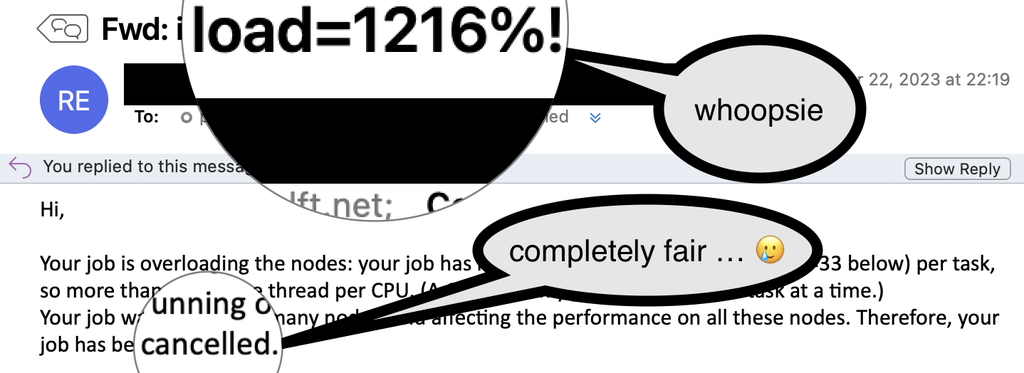

Whoopsie!

# Second Interactive Session: Remote Parallelization

## Tasks (25 min)

1. Install your own Julia version on DelftBlue.
2. Fork and/or clone the julia-hpc-for-dummies repo.
3. Send a job to DelftBlue.